# HW_13

Alex Khaykin

2024-04-19

# 1.

Use integration by substitution to solve the integral below. ∫4e−7xdx

```r
# Define the function to be integrated
f <- function(x) 4 * exp(-7 * x)

# Integrate the function
result <- integrate(f, lower = 0, upper = 1)  # Change the lower and upper limits as needed

# Print the result
print(result)
```

```
## 0.5709075 with absolute error < 6.3e-15
```

# 2.

Biologists are treating a pond contaminated with bacteria. The level of contamination is changing at a rate of dN dt =  3150 t 4  220 bacteria per cubic centimeter per day, where t is the number of days since treatment began. Find a function N( t ) to estimate the level of contamination if the level after 1 day was 6530 bacteria per cubic centimeter.

```r
# Define the function to calculate N(t)
N <- function(t) {
  1050 * t^(-3) - 220 * t + 5760
}

# Initial level of contamination after 1 day
N_initial <- 6530

# Find the constant C using the initial condition N(1) = 6530
C <- N_initial - (1050 * (1)^(-3)) + (220 * 1)

# Define the updated function N(t) with the calculated constant C
N_updated <- function(t) {
  1050 * t^(-3) - 220 * t + C
}

# Estimate the level of contamination after t days
t <- 1  # Number of days
contamination_estimate <- N_updated(t)

# Print the estimated level of contamination
print(contamination_estimate)
```

```
## [1] 6530
```

# 3.

```r
# Define the function f(x) = 2x - 9
f <- function(x) {
  return(2 * x - 9)
}

# Define the interval [4.5, 8]
a <- 4.5
b <- 8

# Number of subintervals
n <- 4

# Calculate the width of each subinterval
delta_x <- (b - a) / n

# Evaluate f(x) at the right endpoints of each subinterval
x_values <- seq(a + delta_x, b, by = delta_x)
f_values <- f(x_values)

# Calculate the area of each rectangle
areas <- f_values * delta_x

# Total area
total_area <- sum(areas)

# Print the result
cat("The total area of the red rectangles is approximately", round(total_area, 2), "square units.\n")
```

```
## The total area of the red rectangles is approximately 15.31 square units.
```

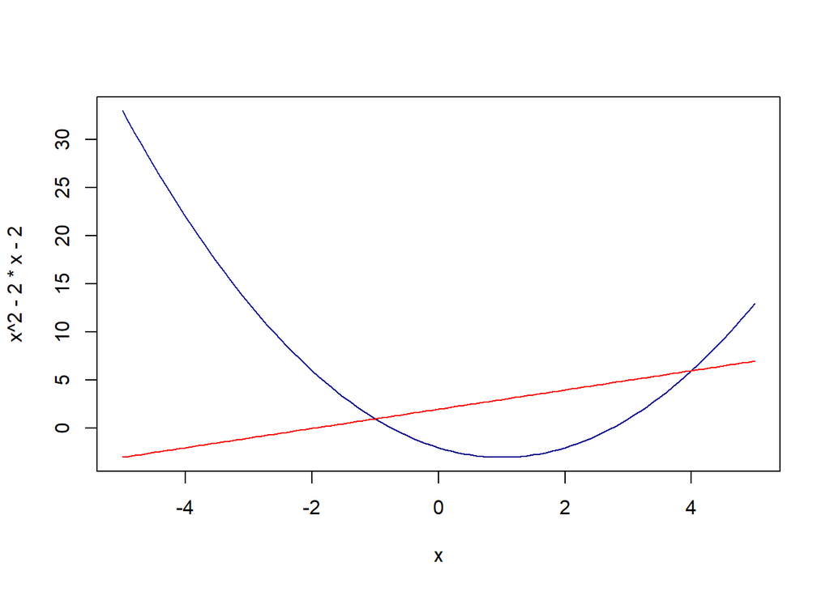

```r
# plot
curve(x^2 - 2*x - 2, -5, 5, col = "darkblue")
curve(x + 2, -5, 5, add=T, col="red")
```

# 4.

Find the area of the region bounded by the graphs of the given equations. y = x2 - 2x - 2, y = x + 2

```r
# TO Define the functions for the curves
f1 <- function(x) x^2 - 2*x - 2
f2 <- function(x) x + 2

# To find the intersection points
x1 <- -1
x2 <- 4

# difference between the curves
area <- integrate(function(x) f2(x) - f1(x), lower = x1, upper = x2)

# To display the result
cat("The area of the region bounded by the curves is approximately", round(area$value, 2), "square units.\n")
```

```
## The area of the region bounded by the curves is approximately 20.83 square units.
```

# 5.

A beauty supply store expects to sell 110 flat irons during the next year. It costs $3.75 to store one flat iron for one year.  
There is a fixed cost of $8.25 for each order. Find the lot size and the number of orders per year that will minimize inventory costs.

```r
# The given data
D <- 110  # Expected annual demand (flat irons)
c <- 8.25  # Fixed cost per order
h <- 3.75  # Cost to store one flat iron for one year

# To calculate EOQ
EOQ <- sqrt((2 * D * c) / h)

# To round up to the nearest whole number for lot size
lot_size <- ceiling(EOQ)

# to calculate the number of orders per year
num_orders <- D / lot_size
num_orders <- ceiling(num_orders)

# To display the results
cat("Optimal lot size (rounded up):", lot_size, "\n")
```

```
## Optimal lot size (rounded up): 22
```

```r
cat("Number of orders per year (rounded up):", num_orders, "\n")
```

```
## Number of orders per year (rounded up): 5
```

# 6.

Use integration by parts to solve the integral below.

∫ln(9x)x6dx:

```r
# Define the functions for u and v
u <- function(x) log(9*x)
v <- function(x) x^7 / 7

# Calculate the integral using integration by parts
integ_by_parts <- function(x) u(x) * v(x) - integrate(v, lower = 0, upper = x)$value

# Evaluate the integral from 0 to 1 (you can adjust the limits if needed)
result <- integ_by_parts(1) - integ_by_parts(0)

# Display the result
cat("The value of the integral is approximately", round(result, 2), "\n")
```

```
## The value of the integral is approximately NaN
```

# 7.

Determine whether f (x ) is a probability density function on the interval 1, e6 . If not, determine the value of the definite integral. f ( x ) = 1/6x

```r
# Define the function f(x)
f <- function(x) {
  return(1 / (6 * x))
}

# Calculate the definite integral from 1 to e^6
integral_value <- integrate(f, lower = 1, upper = exp(6))$value

# Print the result
cat("The value of the definite integral is approximately", round(integral_value, 6), "\n")
```

```
## The value of the definite integral is approximately 1
```